# HMM search output analyses with avg e-val:s

LJM

2019-12-21

# 1 Load libraries

```r
library(tidyverse)
library(vegan)
library(ggbiplot)
```

# 2 Read intermediary `csv` file

In the intermediary `csv` file the $-log_{10}(\text{e-val})$:s are the average e-values of all matches with same HMM profiles to each fOTU.

```r
# Create a character string which determines the column types
columns <- paste("c", strrep("d",8315), sep = "")
fOTUsHMM <- read_csv(file = "../analyses/HMMsearch/avg_fOTUsHMM.csv",
                     col_types = columns)
```

# 3 Exchange NA, Inf and -Inf with 0

```r
is.na(fOTUsHMM) <- sapply(fOTUsHMM, is.infinite)
fOTUsHMM[is.na(fOTUsHMM)] <- 0
```

# 4 Move fOTU names to row names and execute PCA

```r
fOTUsHMM_pca <- fOTUsHMM %>%
  column_to_rownames(var = "fOTU_name") %>%
  prcomp(.,
         center = TRUE)
```

# 5 Visualise the results

```r
file_name <- "../visualisations/HMMsearch/ggbiplot_avg_PC1-2.png"
png(filename = file_name)
ggbiplot(fOTUsHMM_pca, var.axes = F, choices = 1:2)
dev.off()
```

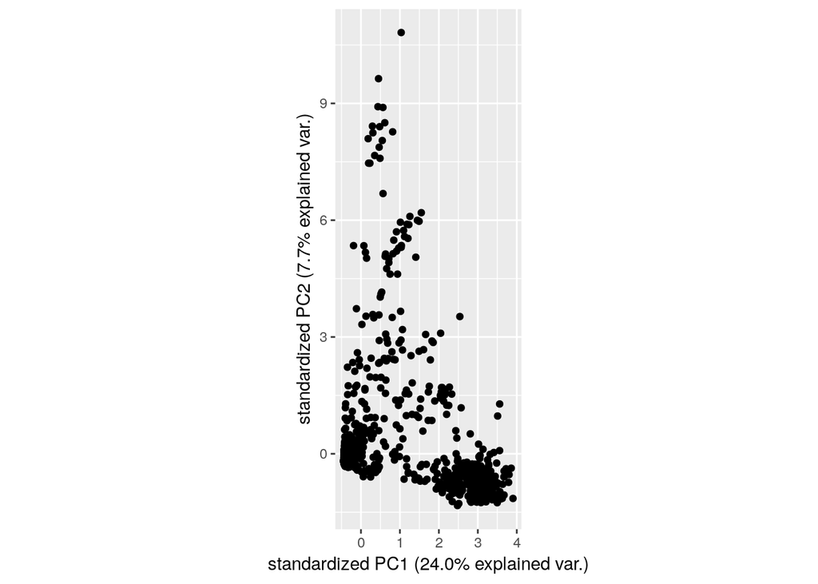

```r
ggbiplot(fOTUsHMM_pca, var.axes = F, choices = 1:2)
```

Here are some heatmaps to visualise how e-values are spread out by principal components and by HMMs.

```r
prediction <- predict(fOTUsHMM_pca)[,1:20]
file_name <- "../visualisations/HMMsearch/heatmap_avg_20_first_PCs.png"
png(filename = file_name)
heatmap(as.matrix(prediction))
dev.off()
```

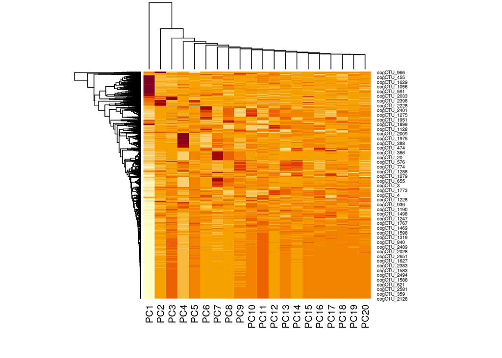

```r
heatmap(as.matrix(prediction))
```

```r
file_name <- "../visualisations/HMMsearch/heatmap_avg_400_first_fOTUs.png"
png(filename = file_name)
heatmap(as.matrix(fOTUsHMM[,-1])[,1:400])
dev.off()
```

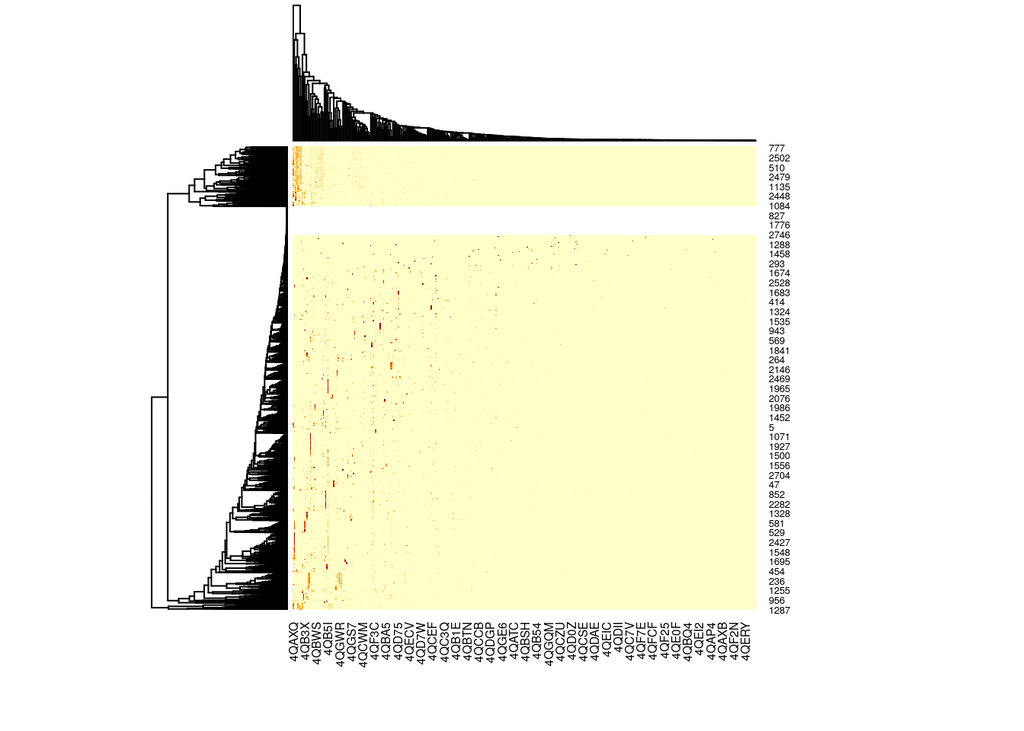

```r
heatmap(as.matrix(fOTUsHMM[,-1])[,1:400])
```

# 6 NMDS

Let’s perform non-metric multidimensional scaling:

```r
width <- dim(fOTUsHMM)[2]
ord_avg <- metaMDS(fOTUsHMM[,2:width])
```

# 7 Save/Load R data

Save or load the data once again to speed-up things.

```r
#saveRDS(ord_avg, file = "../analyses/HMMsearch/R_data/avg_ord.rds")
ord_avg <- readRDS(file = "../analyses/HMMsearch/R_data/avg_ord.rds")
```

How well does the 2-D representation of multidimensional space represent the actual multidimensional space is done by using statistic called stress. Stress < 0.1 indicates that the 2-D representation is a good repreresentation of the multi-D space. Let’s check that out now:

```r
ord_avg$stress
```

```
## [1] 0.05112436
```

This is quite low which is great! Let’s now plot out the relationship between the ordination dissimilarities and the distances in the ordination space:

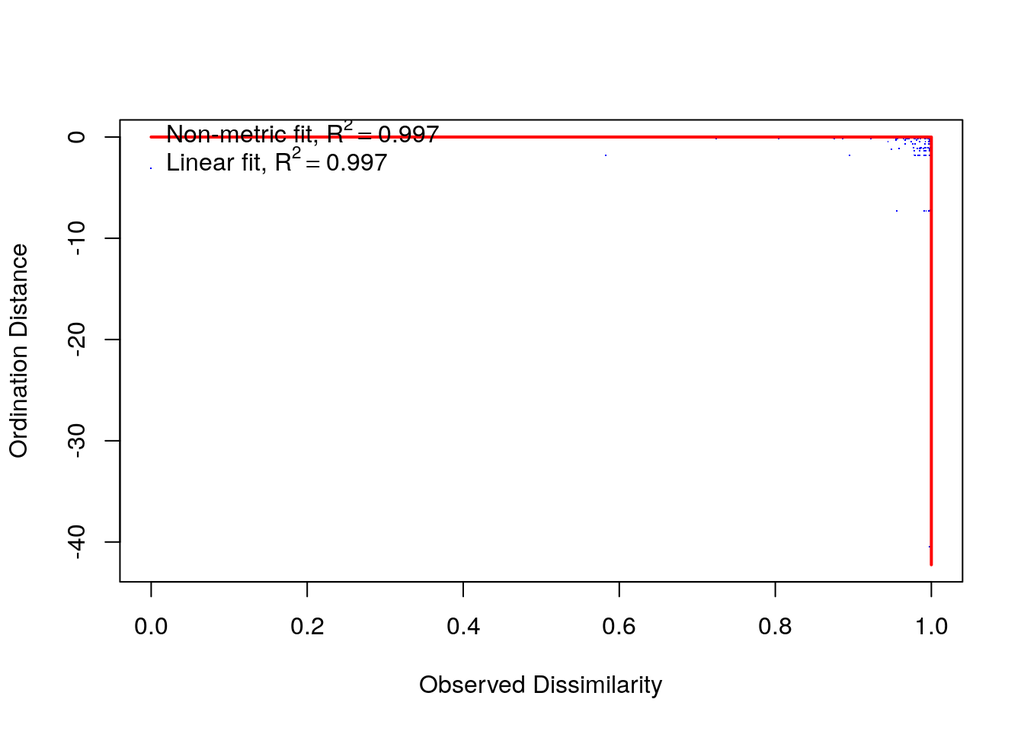

```r
stressplot(ord_avg)
```

Observed dissimilarity of 1 means the fOTU doesn’t have any HMMs incommon with the others.

Let’s plot out the ordination space in 2-d:

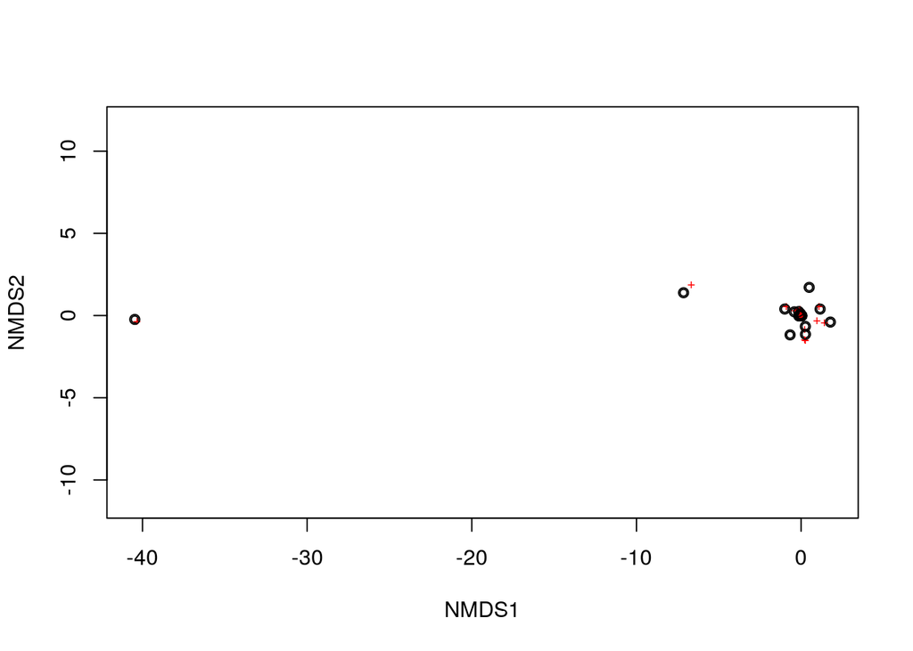

```r
ordiplot(ord_avg)
points(ord_avg)
```

and let’s filter away the outliers and make new plot from above:

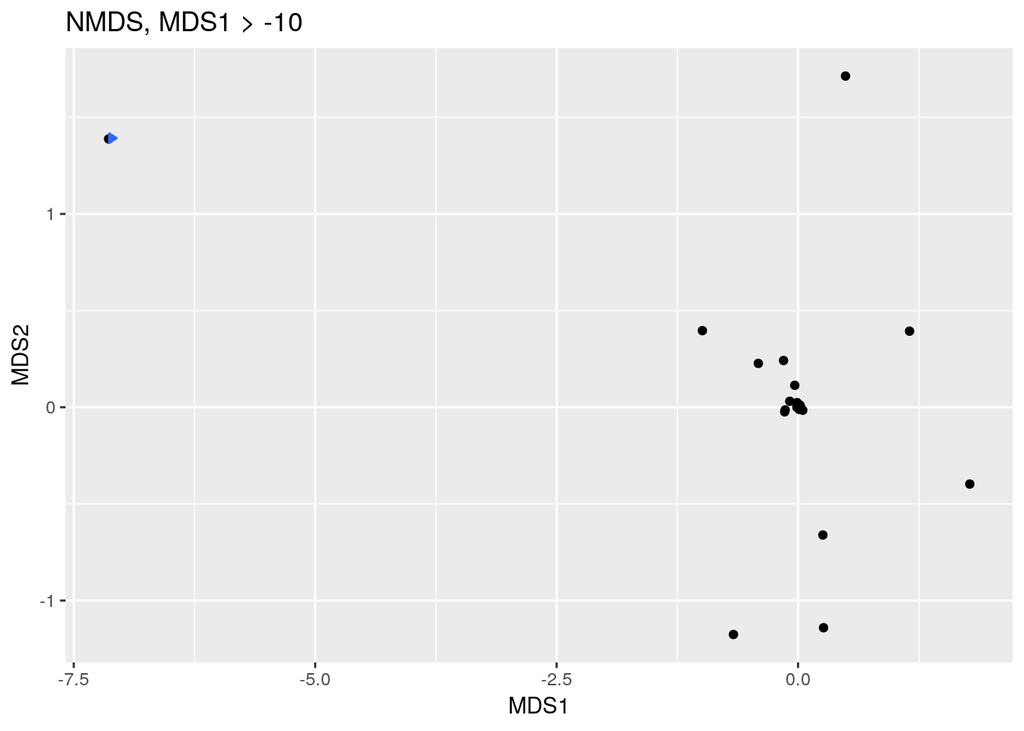

```r
NMDS_points1 <- as_tibble(ord_avg$points) %>%
  filter(MDS1 > -10)

title <- "NMDS, MDS1 > -10"
qplot(MDS1,
      MDS2,
      data = NMDS_points1,
      geom = c("point", "density2d")) + ggtitle(title)
```

```r
path <- "../visualisations/HMMsearch/nmds_hmmsearch_avg_MDS1_greater_than_-10.png"

ggsave(filename = path,
       device = png,
       width = 1000,
       height = 750,
       units = "in",
       limitsize = FALSE,
       dpi = 320)
```

Let’s filter away slightly more:

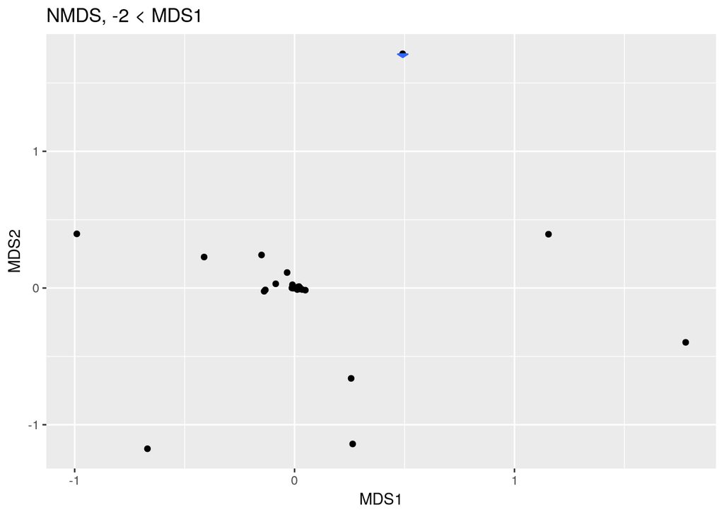

```r
NMDS_points2 <- as_tibble(ord_avg$points) %>%
  filter(MDS1 > -2)

title <- "NMDS, -2 < MDS1"
qplot(MDS1,
      MDS2,
      data = NMDS_points2,
      geom = c("point", "density2d")) + ggtitle(title)
```

```r
path <- "../visualisations/HMMsearch/nmds_hmmsearch_avg_MDS1_greater_than_-2.png"

ggsave(filename = path,
       device = png,
       width = 1000,
       height = 750,
       units = "in",
       limitsize = FALSE,
       dpi = 320)
```

# 8 Create lists of fOTUs of interest

## 8.1 Preview PCA plots

These PCA plots can be used to visually determine potential groupings.

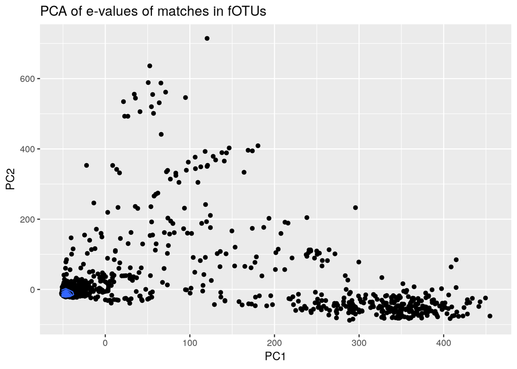

```r
PC12s <- tibble(fOTUs = names(fOTUsHMM_pca$x[,1]),
              PC1 = unname(fOTUsHMM_pca$x[,1]),
              PC2 = unname(fOTUsHMM_pca$x[,2]))

title <- "PCA of e-values of matches in fOTUs"
qplot(PC1,
      PC2,
      data = PC12s,
      geom = c("point", "density2d")) + ggtitle(title)
```

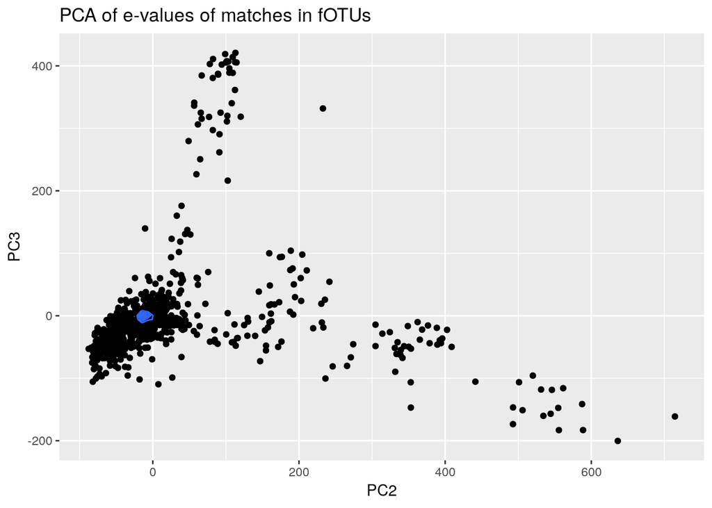

```r
ggsave(filename = "../visualisations/HMMsearch/pca_hmmsearch_avg_PC1-2.png",
       device = png,
       width = 1000,
       height = 750,
       units = "in",
       limitsize = FALSE,
       dpi = 320)

PC23s <- tibble(fOTUs = names(fOTUsHMM_pca$x[,1]),
              PC2 = unname(fOTUsHMM_pca$x[,2]),
              PC3 = unname(fOTUsHMM_pca$x[,3]))

title <- "PCA of e-values of matches in fOTUs"
qplot(PC2,
      PC3,
      data = PC23s,
      geom = c("point", "density2d")) + ggtitle(title)
```

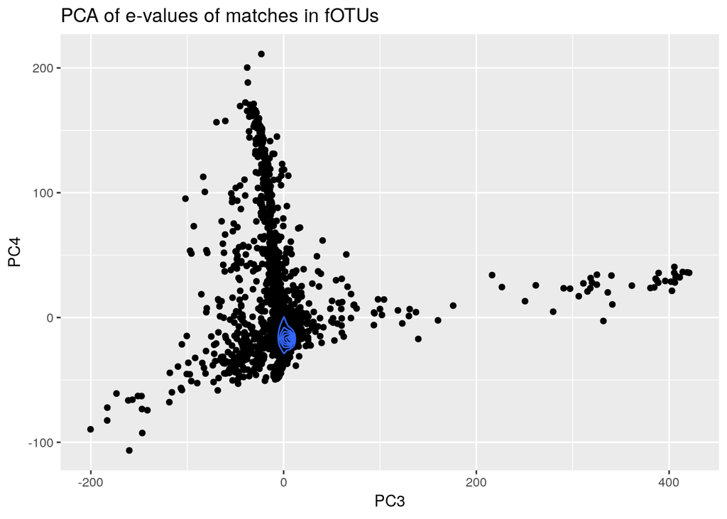

```r
ggsave(filename = "../visualisations/HMMsearch/pca_hmmsearch_avg_PC2-3.png",
       device = png,
       width = 1000,
       height = 750,
       units = "in",
       limitsize = FALSE,
       dpi = 320)

PC34s <- tibble(fOTUs = names(fOTUsHMM_pca$x[,1]),
              PC3 = unname(fOTUsHMM_pca$x[,3]),
              PC4 = unname(fOTUsHMM_pca$x[,4]))

title <- "PCA of e-values of matches in fOTUs"
qplot(PC3,
      PC4,
      data = PC34s,
      geom = c("point", "density2d")) + ggtitle(title)
```

```r
ggsave(filename = "../visualisations/HMMsearch/pca_hmmsearch_avg_PC3-4.png",
       device = png,
       width = 1000,
       height = 750,
       units = "in",
       limitsize = FALSE,
       dpi = 320)
```

## 8.2 Create a file for each list

By comparing visually the PCA data, we can see that they are located essentially in same locations. Thus it is unnecessary to create new lists based on the average e-value points when there already are points based on the maximum e-values.

# 10 References